# Classification modeling on LendingClub’s loan data

Uyemaa Gantulga, Ayush Meshram, Aakash Singh, and Melissa Yago

12/09/24

### Data preparation

```r
# Read large CSV
data <- fread("C:\\Users\\uemaa\\Documents\\Data_Science\\Fin\\Proj1\\cleaned_accepted_2013_to_2018Q4.csv")

df <- data[, c("issue_d", "loan_amnt", "int_rate", "grade", "sub_grade", "emp_length", "annual_inc", "dti", "fico_range_low", "fico_range_high", "last_fico_range_high", "last_fico_range_low", "open_acc_6m","loan_status")]
```

# Introduction

LendingClub is a financial services company that facilitates loan contracts. This analysis examines approved loan data (2013-2018) to identify factors that contribute to loan charge-offs.

**Dataset Overview**: - **Observations**: 2.15 million approved loans - **Goal**: Use predictive modeling to analyze factors affecting loan charge-offs.

# Research Questions

1. **Features Impact**: Which combination of features from our initial EDA (interest rate, grade, annual income, etc.) provides the most reliable predictions of the 2013-2018 loan data?
2. **Model Performance**: How do logistic regression and random forest models compare in their ability to predict loan charge-offs when trained on 2013-2015 data and tested on holdout sets from 2013-2015 and 2016-2018 data?
3. **Prediction Accuracy Across Timeframes**: How accurately can we predict loan charge-offs for loans issued between 2015-2018 that are still active and might charge-off in future, using our 2013-2018 trained models from Question 2?

# Our story

At the start of the semester we were curious about “Data Science”. Some told us “Why not study *statistics* instead!”. But throughout the course DATS6101, we’ve learned what we will be doing as “Data Scientist”. And with our Project One and Two we understood what it means to work with *data*, what it takes to understand it.

We are glad we’ve learned all of these processes we are now reporting on. I hope you’ll have fun reading it, as much fun as we’ve had making this report. Oh the stories we could tell. For now, lets see what our “Lending club dataset” tells us.

Source: https://www.kaggle.com/datasets/wordsforthewise/lending-club Github: https://github.com/aash1999/all-lending-club-loan-data Ppt: https://docs.google.com/presentation/d/173CgDYyy9xvD72MpYmGiLR0wO9Vlwn3U/edit?usp=sharing&ouid=102489423949507971777&rtpof=true&sd=true

# Exploratory Data Analysis

## Summary Statistics of Key Features

- **Loan Amount**: The average loan amount approved for borrowers.
- **Interest Rate**: The average interest rate associated with the loans.
- **Debt-to-Income (DTI) Ratio**: The mean ratio of a borrower’s monthly debt payments to their monthly income.
- **Annual Income**: The average annual income of the borrowers.
- **FICO Score Ranges**: The average low and high ranges of borrowers’ FICO credit scores.

## Question 1: Features Impact

### Overview

The goal is to identify the combination of features that provide the most reliable predictions of loan charge-offs for the 2013-2018 dataset.

This analysis focuses on the following variables:

#### Independent Variables:

1. **Loan Amount**: The total loan amount approved for the borrower.
2. **Interest Rate**: The interest rate associated with the loan.
3. **Grade**: The loan’s credit grade assigned by LendingClub.
4. **Sub Grade**: A finer classification of the credit grade.
5. **DTI (Debt to Income Ratio)**: The borrower’s monthly debt payments divided by their monthly income.
6. **Employment Length**: The borrower’s duration of employment, measured in years.
7. **Annual Income**: The borrower’s yearly income.
8. **open_acc_6m**: Number of open accounts the borrower had in the last six months.
9. **FICO Scores**:
   - **FICO Range High/Low**: The range of the borrower’s credit score at the time of loan issuance.
   - **Latest FICO Range High/Low**: The most recent range of the borrower’s credit score.

#### Dependent Variable:

- **Loan Status**: The outcome of the loan, categorized as either “Charged Off” (defaulted loans) or “Fully Paid” (successfully repaid loans).

### Significance of Variables

Each independent variable contributes to the prediction of loan charge-offs:

- **Loan Amount**: Larger loans may have higher risk due to greater financial burden.
- **Interest Rate**: Higher interest rates often correlate with riskier loans.
- **Grade and Sub Grade**: Indicators of creditworthiness; lower grades suggest higher risk.
- **DTI**: High DTI ratios indicate borrowers with financial strain, increasing default risk.
- **Employment Length**: Longer employment may indicate financial stability.
- **Annual Income**: Higher income reduces the likelihood of default.
- **open_acc_6m**: Indicates the borrower’s recent credit activity, which could reflect their financial behavior.
- **FICO Scores**: Key indicators of a borrower’s creditworthiness.

## Loan Analysis

### Loan Repayment Rate by Grade

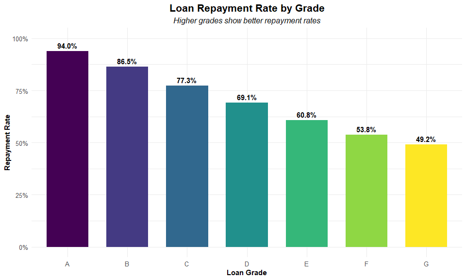

The bar chart below shows the repayment rates across different loan grades. It highlights that higher grades (e.g., A and B) have significantly better repayment rates compared to lower grades (e.g., F and G).

### Comparison of Loan Variables (2014 vs. 2017)

The radar chart below compares various loan characteristics (e.g., interest rates, FICO scores, DTI) between 2014 and 2017. This helps us observe changes in borrower profiles over time.

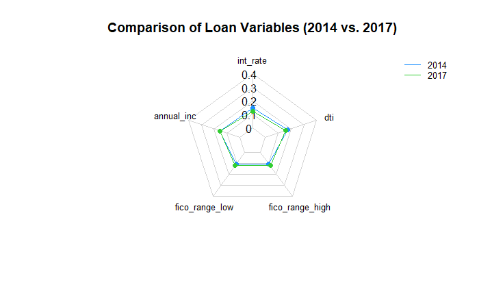

```r
knitr::include_graphics("C:\\Users\\uemaa\\Documents\\Data_Science\\Fin\\Proj2\\images\\Comp_loan_variables.png")
```

Key Insight:

FICO scores and debt-to-income ratios remained relatively stable. Interest rates show slight variation, reflecting adjustments in lending policies.

### Distribution of Loan Amounts

The histogram below represents the distribution of loan amounts for accepted loans. Most loans fall between $5,000 and $20,000, with a peak at $10,000.

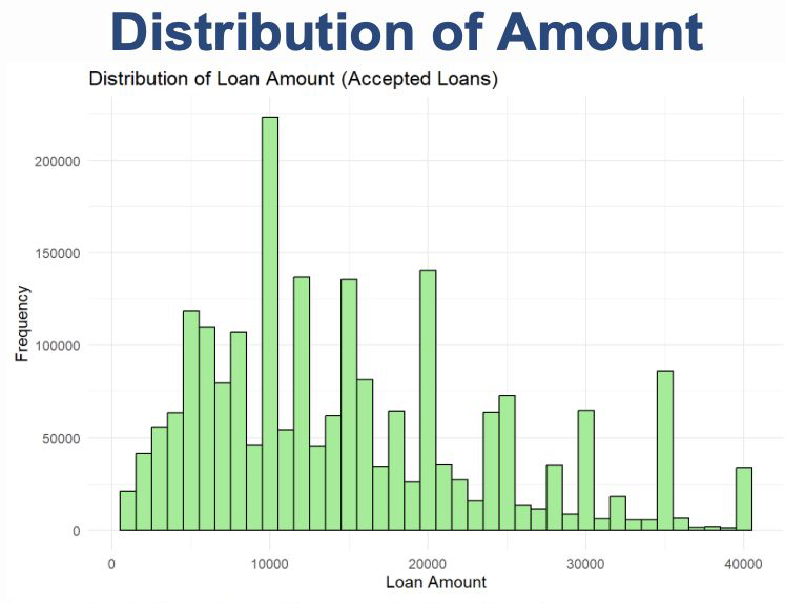

```r
knitr::include_graphics("C:\\Users\\uemaa\\Documents\\Data_Science\\Fin\\Proj2\\images\\distribution_accepted.png")
```

Key Insight: Loan amounts are concentrated around the $10,000 mark. Larger loans ($30,000 or more) are less frequent but still significant in volume.

### Initial Findings from EDA

The exploratory data analysis (EDA) revealed the following key insights: 1. **Interest Rate and Grade** are strongly associated with loan outcomes: - Higher grades (A, B) correspond to better repayment rates. - Higher interest rates correlate with increased default risk. 2. **Annual Income and DTI** provide moderate predictive power: - Borrowers with higher incomes and lower DTI ratios exhibit fewer charge-offs. 3. **FICO Scores** are critical predictors: - Borrowers with higher FICO ranges are significantly less likely to default.

### Feature Selection and Justification

Based on EDA and initial modeling results: - All selected features are statistically significant predictors of loan outcomes. - **FICO Scores, Interest Rate, and Grade** are the strongest predictors, providing high reliability for predicting loan charge-offs. - Secondary predictors, such as **Loan Amount, Annual Income, and Employment Length**, add incremental value to the model.

These features form the foundation for the subsequent predictive modeling discussed in the next sections.

## Question 2: Model Performance

### Overview

To compare the performance of logistic regression and random forest models in predicting loan charge-offs, we trained both models on data from 2013-2015 and tested them on two holdout datasets: 1. **2013-2015 Test Set**: To evaluate in-sample performance. 2. **2016-2018 Test Set**: To evaluate out-of-sample performance and generalizability.

### Data Preparation

```r
# Splitting the dataset
library(caret)

set.seed(123)
split <- createDataPartition(df$loan_status, p = 0.7, list = FALSE)
train_data <- df[split, ]
temp_data <- df[-split, ]

split_eval <- createDataPartition(temp_data$loan_status, p = 0.5, list = FALSE)
eval_data <- temp_data[split_eval, ]
test_data <- temp_data[-split_eval, ]

# Check dimensions
dim(train_data)
```

```
## [1] 1510528      14
```

```r
dim(eval_data)
```

```
## [1] 323684     14
```

```r
dim(test_data)
```

```
## [1] 323682     14
```

```r
#For Question #2
#Load 2013-2015 Train Data
train_data <-read.csv("C:\\Users\\uemaa\\Documents\\Data_Science\\Fin\\Proj2\\data_2013_2015_train.csv")

#Convert Loan Status to Numeric Values \ 1= Charged Off 0 = Fully Paid
train_data$loan_status <- ifelse(train_data$loan_status == "Charged Off", 1,0)

#Load Test Data 2013-2015
test_data <-read.csv("C:\\Users\\uemaa\\Documents\\Data_Science\\Fin\\Proj2\\data_2013_2015_test.csv")

#Convert Loan Status to Numeric Values \ 1= Charged Off 0 = Fully Paid
test_data$loan_status <- ifelse(test_data$loan_status == "Charged Off", 1,0)

#Load Test Data 2016-2018
test_data_2 <-read.csv("C:\\Users\\uemaa\\Documents\\Data_Science\\Fin\\Proj2\\data_2016_2018_test.csv")

#Convert Loan Status to Numeric Values \ 1= Charged Off 0 = Fully Paid
test_data_2$loan_status <- ifelse(test_data_2$loan_status == "Charged Off", 1,0)


#For Question #3
#Load Active Loans Data
active_data <-read.csv("C:\\Users\\uemaa\\Documents\\Data_Science\\Fin\\Proj2\\predict.csv")

#Load 2013-2018 Train Data
all_train_data <-read.csv("C:\\Users\\uemaa\\Documents\\Data_Science\\Fin\\Proj2\\train.csv")

#Convert Loan Status to Numeric Values \ 1= Charged Off 0 = Fully Paid
all_train_data$loan_status <- ifelse(all_train_data$loan_status == "Charged Off", 1,0)
```

# Question #2: How do different classification models (logistic regression and classification tree) compare in their ability to predict loan charge-offs when trained on 2013-2015 data and tested on holdout sets from 2013-2015 and 2016-2018 data?

## Logistic Regression Model Performance

### Model Training on 2013-2015 Data

The logistic regression model was trained on the 2013-2015 data with the following independent variables: - Loan Amount - Interest Rate - Grade - Sub Grade - DTI - Employment Length - Annual Income

```r
#Logistic Regression Model
log_model <-glm(loan_status ~ loan_amnt + int_rate + grade + sub_grade + dti + emp_length + annual_inc, data = train_data, family = binomial)

#Summary of Model
summary(log_model)
```

```
##
## Call:
## glm(formula = loan_status ~ loan_amnt + int_rate + grade + sub_grade +
##     dti + emp_length + annual_inc, family = binomial, data = train_data)
##
## Coefficients:
##                     Estimate Std. Error z value Pr(>|z|)
## (Intercept)         -3.95952    0.04456   -88.8   <2e-16 ***
## loan_amnt            0.12989    0.00447    29.1   <2e-16 ***
## int_rate            -0.62360    0.02186   -28.5   <2e-16 ***
## gradeB               1.34140    0.02408    55.7   <2e-16 ***
## gradeC               2.39642    0.03603    66.5   <2e-16 ***
## gradeD               3.25656    0.05043    64.6   <2e-16 ***
## gradeE               4.01304    0.06333    63.4   <2e-16 ***
## gradeF               4.78972    0.08223    58.2   <2e-16 ***
## gradeG               5.29311    0.09833    53.8   <2e-16 ***
## sub_grade            0.19060    0.00408    46.7   <2e-16 ***
## dti                  0.18614    0.00527    35.3   <2e-16 ***
## emp_length< 1 year  -0.23761    0.01992   -11.9   <2e-16 ***
## emp_length1 year    -0.24739    0.02089   -11.8   <2e-16 ***
## emp_length10+ years -0.35797    0.01643   -21.8   <2e-16 ***
## emp_length2 years   -0.30742    0.01959   -15.7   <2e-16 ***
## emp_length3 years   -0.29417    0.02005   -14.7   <2e-16 ***
## emp_length4 years   -0.27324    0.02165   -12.6   <2e-16 ***
## emp_length5 years   -0.27179    0.02133   -12.7   <2e-16 ***
## emp_length6 years   -0.27297    0.02287   -11.9   <2e-16 ***
## emp_length7 years   -0.30784    0.02246   -13.7   <2e-16 ***
## emp_length8 years   -0.25493    0.02221   -11.5   <2e-16 ***
## emp_length9 years   -0.24424    0.02384   -10.2   <2e-16 ***
## annual_inc          -0.16684    0.00772   -21.6   <2e-16 ***
## ---
## Signif. codes:  0 '***' 0.001 '**' 0.01 '*' 0.05 '.' 0.1 ' ' 1
##
## (Dispersion parameter for binomial family taken to be 1)
##
##     Null deviance: 492637  on 508725  degrees of freedom
## Residual deviance: 450132  on 508703  degrees of freedom
##   (2 observations deleted due to missingness)
## AIC: 450178
##
## Number of Fisher Scoring iterations: 5
```

### Model Evaluation on 2013-2015 Test Data

The trained logistic regression model was evaluated using test data from 2013-2015.

Results: Confusion Matrix:

87,900 True Negatives (Fully Paid loans correctly predicted) 19,849 False Negatives (Charged Off loans misclassified as Fully Paid) 529 False Positives (Fully Paid loans misclassified as Charged Off) 527 True Positives (Charged Off loans correctly predicted) Performance Metrics:

ROC Curve & AUC

AUC 0.705: On average, the model has a 70.5% chance of distinguishing between a loan that gets charged off and one that is fully paid. Overall, this model has a moderate ability to distinguish between charged off and fully paid loans when applied to unseen data from 2013-2015.

```r
#libraries
library(caret)
library(pROC)

#Predict on test data
log_predict <- predict(log_model, test_data, type = "response")

#Convert Probabilities to Class
log_predict_class <- ifelse(log_predict > 0.5, 1, 0)

#Covert Predicted and Actual to Factors with Same Levels
log_predict_class <-factor(log_predict_class, levels = c(0,1)) # Predicted Classes
test_data$loan_status <-factor(test_data$loan_status, levels = c(0,1)) # Actual Classes

#Confusion Matrix
con_matrix <- confusionMatrix(as.factor(log_predict_class), test_data$loan_status)
print(con_matrix)
```

```
## Confusion Matrix and Statistics
##
##           Reference
## Prediction     0     1
##          0 87900 19849
##          1   529   527
##
##                Accuracy : 0.813
##                  95% CI : (0.81, 0.815)
##     No Information Rate : 0.813
##     P-Value [Acc > NIR] : 0.508
##
##                   Kappa : 0.031
##
##  Mcnemar's Test P-Value : <2e-16
##
##             Sensitivity : 0.9940
##             Specificity : 0.0259
##          Pos Pred Value : 0.8158
##          Neg Pred Value : 0.4991
##              Prevalence : 0.8127
##          Detection Rate : 0.8079
##    Detection Prevalence : 0.9903
##       Balanced Accuracy : 0.5099
##
##        'Positive' Class : 0
##
```

```r
#ROC Curve and AUC
roc_curve <-roc(test_data$loan_status, as.numeric(log_predict))
auc_value <- auc(roc_curve)
print(auc_value)
```

```
## Area under the curve: 0.705
```

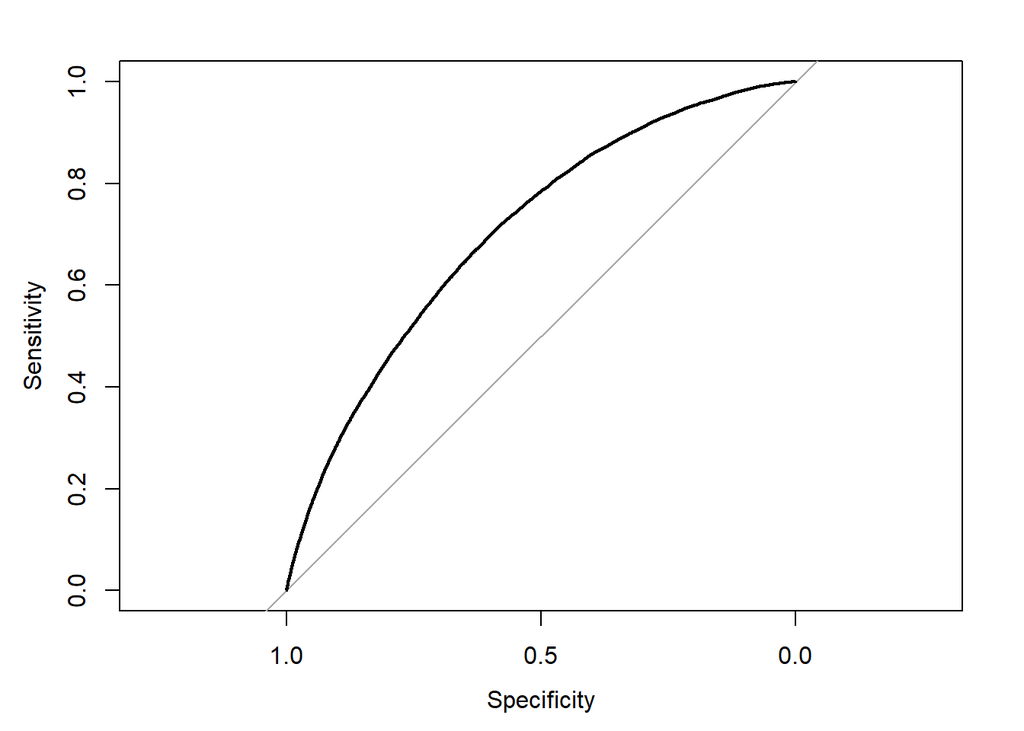

```r
plot(roc_curve)
```

### Model Evaluation on 2016-2018 Test Data

The same model was evaluated on out-of-sample test data (2016-2018) to assess its generalizability.

Results: Confusion Matrix:

60,146 True Negatives 17,415 False Negatives 188 False Positives 177 True Positives Performance Metrics:

```r
#libraries
library(caret)
library(pROC)

#Predict on test data
log_predict_2 <- predict(log_model, test_data_2, type = "response")

#Convert Probabilities to Class
log_predict_class_2 <- ifelse(log_predict_2 > 0.5, 1, 0)

#Covert Predicted and Actual to Factors with Same Levels
log_predict_class_2 <-factor(log_predict_class_2, levels = c(0,1)) # Predicted Classes
test_data_2$loan_status <-factor(test_data_2$loan_status, levels = c(0,1)) # Actual Classes

#Confusion Matrix
con_matrix_2 <- confusionMatrix(as.factor(log_predict_class_2), test_data_2$loan_status)
print(con_matrix_2)
```

```
## Confusion Matrix and Statistics
##
##           Reference
## Prediction     0     1
##          0 60146 17415
##          1   188   177
##
##                Accuracy : 0.774
##                  95% CI : (0.771, 0.777)
##     No Information Rate : 0.774
##     P-Value [Acc > NIR] : 0.54
##
##                   Kappa : 0.011
##
##  Mcnemar's Test P-Value : <2e-16
##
##             Sensitivity : 0.9969
##             Specificity : 0.0101
##          Pos Pred Value : 0.7755
##          Neg Pred Value : 0.4849
##              Prevalence : 0.7742
##          Detection Rate : 0.7718
##    Detection Prevalence : 0.9953
##       Balanced Accuracy : 0.5035
##
##        'Positive' Class : 0
##
```

```r
#ROC Curve and AUC
roc_curve_2 <-roc(test_data_2$loan_status, as.numeric(log_predict_2))
auc_value_2 <- auc(roc_curve_2)
print(auc_value_2)
```

```
## Area under the curve: 0.696
```

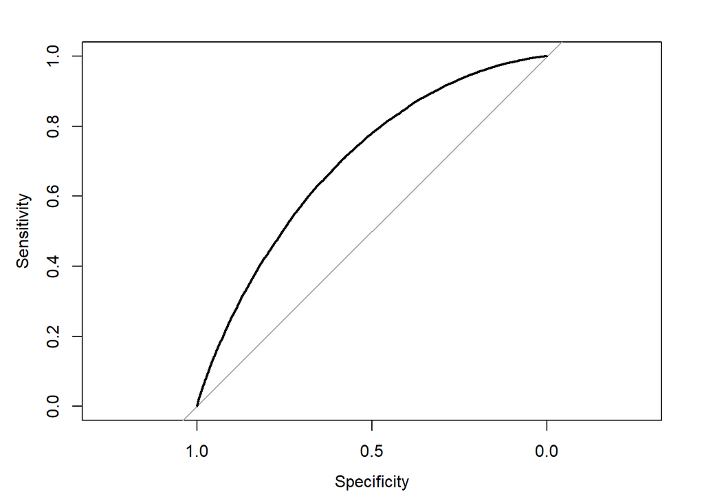

```r
plot(roc_curve_2)
```

Interpretation:

The model’s performance declines slightly on out-of-sample data, likely due to differences in borrower behavior or economic conditions after 2015. Improvements in feature selection or training data updates could improve generalizability.

To improve predictions, the following are considered:

Adjusting the probability threshold (e.g., >0.7 for higher confidence in classifying charged off loans). Incorporating additional predictors (e.g., FICO scores or recent credit activity). Combining with more complex models like Random Forests, which handle non-linear relationships and imbalanced classes better.

# 3. How accurately can we predict loan charge-offs for Lending Club loans issued between 2015-2018 that are still active and might charge-off in future, using our 2013-2018 trained models from Question #2?

## Logistic Regression Model

After using 2013-2018 data to train the logistic regression model, we can then use this model to predict how much active loans from 2015-2018 will charge off. After predicting probabilities and using a probability threshold of 0.5, the model predicts that there’s a higher than 50% risk of 115,242 active loans being charged off. On the other hand, the model predicts that there’s a 50% or lower risk of 748,371 active loans being charged off.

By raising the threshold from 0.5 to 0.7, the model becomes more conservative in classifying loans as charged off. As a result, fewer loans are categorized as charged off because the model now requires a higher confidence greater greater than 70% to make this prediction.

Based on this analysis for logistic regression, we anticipate 115,242 current loans to be charged off with a 0.5 probability threshold and 76,601 current loans to be charged off with a 0.7 probability threshold.

*0.5 Probability Threshold For Predicting Charge-Offs Table*

```r
#library
library(dplyr)
#Train Logistic Regression Model using 2013-2018 trained data
active_model <-glm(loan_status ~ loan_amnt + int_rate + grade + sub_grade + dti + emp_length + last_fico_range_high + last_fico_range_low + fico_range_low + fico_range_high + open_acc_6m + annual_inc, data = all_train_data, family = binomial)

#Predict Probabilities
active_data$predicted_prob <-predict(active_model, newdata = active_data, type = "response")

#Classify loans based on probability threshold
active_data <-active_data %>%
  mutate(predicted_risk = ifelse(!is.na(predicted_prob) & predicted_prob > 0.5, "Charged Off", "Fully Paid"))

#Summary of Predicted Charge-Offs
table(active_data$predicted_risk)
```

```
##
## Charged Off  Fully Paid
##      115242      748371
```

### 0.7 Probabability Threshold For Predicting Charge-Offs Table

```r
#Classify loans based on probability threshold
active_data <-active_data %>%
  mutate(predicted_risk = ifelse(!is.na(predicted_prob) & predicted_prob > 0.7, "Charged Off", "Fully Paid"))

#Summary of Predicted Charge-Offs
table(active_data$predicted_risk)
```

```
##
## Charged Off  Fully Paid
##       76601      787012
```

## Insights and Observations

***Threshold Impact:**

*Lowering the threshold to 0.5* increases sensitivity but also increases false positives (more loans classified as “Charged Off”). *Raising the threshold to 0.7* reduces false positives but risks missing loans that are likely to charge off.

Distribution of Predicted Risk:

With a 0.5 threshold, ~13% of loans are flagged as high risk. With a 0.7 threshold, only ~8% of loans are flagged, indicating a stricter classification criterion.

*Model Limitations:*

The model’s accuracy in predicting active loan outcomes may be impacted by changes in borrower behavior or economic factors after 2018. Additional features, such as macroeconomic variables or updated credit scores, could improve predictions.

###Logistic regression model analysis:

The logistic regression model provides a reasonable prediction of charge-offs for active loans from 2015-2018:

A threshold of 0.5 is more sensitive, flagging more loans as “Charged Off.” A threshold of 0.7 is more conservative, reducing the number of false positives but risking higher false negatives.

# Question #3: Prediction Accuracy Across Timeframes (Random Forest)

## Overview

The Random Forest model was trained on 2013-2018 data and applied to predict loan charge-offs for active loans issued between 2015-2018. This method leverages Random Forest’s ability to handle: - Non-linear relationships - Imbalanced classes - Feature importance analysis - Regularization and robustness to noisy data

## Data Preparation

### Data Splitting

The dataset was split into: - **Training Set**: 70% - **Evaluation Set**: 15% - **Test Set**: 15%

```r
train_df_path = "C:\\Users\\uemaa\\Documents\\Data_Science\\Fin\\Proj2\\train.csv"
eval_df_path = "C:\\Users\\uemaa\\Documents\\Data_Science\\Fin\\Proj2\\eval.csv"
test_df_path = "C:\\Users\\uemaa\\Documents\\Data_Science\\Fin\\Proj2\\test.csv"
predict_df_path = "C:\\Users\\uemaa\\Documents\\Data_Science\\Fin\\Proj2\\predict.csv"

train_df = fread(train_df_path)
eval_df = fread(eval_df_path)
test_df = fread(test_df_path)
predict_df = fread(predict_df_path)

target_column <- "loan_status"
```

## *Exploratory Data Analysis (EDA)*

## Class Distribution

[figure not shown]

```r
loan_status_counts <- table(train_df$loan_status)


loan_status_percentages <- round(100 * loan_status_counts / sum(loan_status_counts), 1)

loan_status_df <- data.frame(
  status = names(loan_status_counts),
  count = as.numeric(loan_status_counts),
  percentage = loan_status_percentages
)


ggplot(loan_status_df, aes(x = "", y = count, fill = status)) +
  geom_bar(stat = "identity", width = 1) +
  coord_polar(theta = "y") +
  labs(title = "Distribution of Charged Off vs Fully Paid Loans") +
  theme_void() +
  scale_fill_manual(values = c("Charged Off" = "red", "Fully Paid" = "green")) +
  geom_text(aes(label = paste0(loan_status_df$percentage, "%")), position = position_stack(vjust = 0.5))  # Add percentages
```

Preparation of Data

```r
describe_df <- function(df){
  print(summary(df))
  print(describe(df))
  print(colnames(df))
  sapply(df, class)
  missing_percentage <- sapply(df, function(x) sum(is.na(x)) / nrow(df) * 100)
  missing_percentage_df <- data.frame(Column = names(missing_percentage),
                                    Missing_Percentage = missing_percentage)
  print(missing_percentage_df)
}
prepare_and_clean_data <- function(df) {

  if (inherits(df, "data.table")) {
    df <- as.data.frame(df)
  }

  if (!is.data.frame(df)) {
    stop("Input is not a dataframe")
  }

  if ("loan_status" %in% names(df)) {
    df <- df[!is.na(df$loan_status), ]
    df$loan_status <- factor(df$loan_status)
  }

  if ("issue_d" %in% names(df)) {
    df <- df[, !(names(df) %in% "issue_d")]
  }

  if ("grade" %in% names(df)) {
    df$grade <- factor(df$grade)
  }
  if ("sub_grade" %in% names(df)) {
    df$sub_grade <- factor(df$sub_grade)
  }
  if ("emp_length" %in% names(df)) {
    df$emp_length <- factor(df$emp_length)
  }

  num_cols <- sapply(df, is.numeric)
  df[, num_cols] <- lapply(df[, num_cols, drop = FALSE], function(col) {
    col[is.na(col)] <- median(col, na.rm = TRUE)
    return(col)
  })

  factor_cols <- sapply(df, is.factor)
  df[, factor_cols] <- lapply(df[, factor_cols, drop = FALSE], function(col) {
    mode <- names(sort(table(col), decreasing = TRUE))[1]
    col[is.na(col)] <- mode
    return(col)
  })

  return(df)
}


train_df <- prepare_and_clean_data(train_df)
eval_df <- prepare_and_clean_data(eval_df)
test_df <- prepare_and_clean_data(test_df)
predict_df <- prepare_and_clean_data(predict_df)

describe_df(train_df)
```

```
##    loan_amnt         int_rate     grade      sub_grade      emp_length
##  Min.   :-1.547   Min.   :-1.65   A:149258   1:188135   10+ years:290836
##  1st Qu.:-0.748   1st Qu.:-0.73   B:251751   2:171823   2 years  : 78549
##  Median :-0.292   Median :-0.11   C:251769   3:167430   3 years  : 69417
##  Mean   : 0.001   Mean   : 0.00   D:131137   4:172690   < 1 year : 69110
##  3rd Qu.: 0.621   3rd Qu.: 0.57   E: 61099   5:171622   1 year   : 56990
##  Max.   : 2.904   Max.   : 3.69   F: 20781              5 years  : 53000
##                                   G:  5905              (Other)  :253798
##    annual_inc         dti       fico_range_low  fico_range_high
##  Min.   : -1.1   Min.   :-1.7   Min.   :-1.12   Min.   :-1.12
##  1st Qu.: -0.4   1st Qu.:-0.6   1st Qu.:-0.81   1st Qu.:-0.81
##  Median : -0.2   Median :-0.1   Median :-0.17   Median :-0.17
##  Mean   :  0.0   Mean   : 0.0   Mean   : 0.00   Mean   : 0.00
##  3rd Qu.:  0.2   3rd Qu.: 0.5   3rd Qu.: 0.46   3rd Qu.: 0.46
##  Max.   :154.7   Max.   :86.2   Max.   : 4.75   Max.   : 4.78
##
##  last_fico_range_high last_fico_range_low  open_acc_6m         loan_status
##  Min.   :-8.31        Min.   :-4.93       Min.   :-0.87   Charged Off:177237
##  1st Qu.:-0.65        1st Qu.:-0.29       1st Qu.:-0.04   Fully Paid :694463
##  Median : 0.21        Median : 0.23       Median :-0.04
##  Mean   : 0.00        Mean   : 0.00       Mean   :-0.02
##  3rd Qu.: 0.70        3rd Qu.: 0.53       3rd Qu.:-0.04
##  Max.   : 2.13        Max.   : 1.39       Max.   :13.19
##
```

```
##                      vars      n  mean   sd median   min    max  range  skew
## loan_amnt               1 871700  0.00 1.00  -0.29 -1.55   2.90   4.45  0.77
## int_rate                2 871700  0.00 1.00  -0.11 -1.65   3.69   5.34  0.73
## grade                   3 871700   NaN   NA     NA   Inf   -Inf   -Inf    NA
## sub_grade               4 871700   NaN   NA     NA   Inf   -Inf   -Inf    NA
## emp_length              5 871700   NaN   NA     NA   Inf   -Inf   -Inf    NA
## annual_inc              6 871700  0.00 1.00  -0.17 -1.09 154.66 155.75 48.24
## dti                     7 871700  0.00 1.00  -0.06 -1.72  86.20  87.91 28.04
## fico_range_low          8 871700  0.00 1.00  -0.17 -1.12   4.75   5.87  1.33
## fico_range_high         9 871700  0.00 1.00  -0.17 -1.12   4.78   5.90  1.33
## last_fico_range_high   10 871700  0.00 1.00   0.21 -8.31   2.13  10.44 -0.60
## last_fico_range_low    11 871700  0.00 1.00   0.23 -4.93   1.39   6.32 -3.22
## open_acc_6m            12 871700 -0.02 0.66  -0.04 -0.87  13.19  14.06  2.56
## loan_status            13 871700   NaN   NA     NA   Inf   -Inf   -Inf    NA
##                      kurtosis se
## loan_amnt               -0.12  0
## int_rate                 0.52  0
## grade                      NA NA
## sub_grade                  NA NA
## emp_length                 NA NA
## annual_inc            5181.71  0
## dti                   2172.42  0
## fico_range_low           1.85  0
## fico_range_high          1.85  0
## last_fico_range_high     0.14  0
## last_fico_range_low     13.34  0
## open_acc_6m             14.01  0
## loan_status                NA NA
##  [1] "loan_amnt"            "int_rate"             "grade"
##  [4] "sub_grade"            "emp_length"           "annual_inc"
##  [7] "dti"                  "fico_range_low"       "fico_range_high"
## [10] "last_fico_range_high" "last_fico_range_low"  "open_acc_6m"
## [13] "loan_status"
##                                    Column Missing_Percentage
## loan_amnt                       loan_amnt                  0
## int_rate                         int_rate                  0
## grade                               grade                  0
## sub_grade                       sub_grade                  0
## emp_length                     emp_length                  0
## annual_inc                     annual_inc                  0
## dti                                   dti                  0
## fico_range_low             fico_range_low                  0
## fico_range_high           fico_range_high                  0
## last_fico_range_high last_fico_range_high                  0
## last_fico_range_low   last_fico_range_low                  0
## open_acc_6m                   open_acc_6m                  0
## loan_status                   loan_status                  0
```

### Fetch N Random Observations

Handling Class Imbalance Loan data often exhibits class imbalance, where the number of fully paid loans significantly outweighs the number of charged-off loans. This imbalance can lead to biased model predictions, as the model may favor the majority class to optimize overall accuracy while neglecting the minority class (charged-off loans).

To address this issue, the following techniques were applied during data preparation and modeling:

Random Sampling and Oversampling:

A subset of the data was randomly sampled to create a smaller working dataset for training and evaluation. Within the sampled dataset, the minority class (charged-off loans) was oversampled to match the size of the majority class (fully paid loans). This ensured that the model had an equal representation of both classes during training, improving its ability to identify charged-off loans

```r
handle_class_imbalance <- function(df, target_column) {

  sampled_df <- df %>% sample_n(1000)


  class_distribution <- table(sampled_df[[target_column]])


  minority_class <- names(sort(class_distribution))[which.min(class_distribution)]
  majority_class <- names(sort(class_distribution))[which.max(class_distribution)]


  minority_count <- class_distribution[minority_class]
  majority_count <- class_distribution[majority_class]


  if (minority_count < majority_count) {

    n_oversample <- majority_count - minority_count
    minority_df <- sampled_df[sampled_df[[target_column]] == minority_class, ]


    oversampled_minority <- minority_df[sample(1:nrow(minority_df), n_oversample, replace = TRUE), ]


    balanced_df <- rbind(sampled_df[sampled_df[[target_column]] == majority_class, ], oversampled_minority)
  } else {

    balanced_df <- sampled_df
  }

  return(balanced_df)
}
```

# Training and Evaluating Random Forest

The *train_and_evaluate_rf* function builds a Random Forest model on the training data and evaluates its performance on both the training and evaluation datasets. Additionally, it calculates confusion matrices for further analysis.

*Key Parameters:*

train_df and eval_df: The training and evaluation datasets. target_column: The target variable (in this case, loan_status). Hyperparameters: ntree: Number of trees in the forest. maxnodes: Maximum terminal nodes allowed per tree. maxdepth: Maximum depth of each tree. nodesize: Minimum size of terminal nodes. mtry: Number of variables randomly sampled at each split (default is square root of predictors). classwt: Weights assigned to each class to handle class imbalance.

Function Implementation:

```r
train_and_evaluate_rf <- function(train_df, eval_df, target_column,
                                   ntree = 100, maxnodes = 50, maxdepth = 10,
                                   nodesize = 5, mtry = NULL,
                                   sampsize = NULL, classwt = NULL) {

  formula <- as.formula(paste(target_column, "~ ."))


  if (is.null(mtry)) {
    mtry <- sqrt(ncol(train_df) - 1)
  }
  if (is.null(sampsize)) {
    sampsize <- nrow(train_df)
  }

  rf_model <- randomForest(formula, data = train_df, ntree = ntree, maxnodes = maxnodes,
                           maxdepth = maxdepth, nodesize = nodesize, mtry = mtry,
                           sampsize = sampsize, classwt = classwt, importance = TRUE)



  train_pred <- predict(rf_model, train_df, type = "response")
  train_accuracy <- mean(train_pred == train_df[[target_column]])


  eval_pred <- predict(rf_model, eval_df, type = "response")
  eval_accuracy <- mean(eval_pred == eval_df[[target_column]])


  train_confusion_matrix <- table(Predicted = train_pred, Actual = train_df[[target_column]])
  eval_confusion_matrix <- table(Predicted = eval_pred, Actual = eval_df[[target_column]])




  return(list(
    train_accuracy = train_accuracy,
    eval_accuracy = eval_accuracy,
    train_confusion_matrix = train_confusion_matrix,
    eval_confusion_matrix = eval_confusion_matrix,
    model = rf_model
  ))
}
```

### Calculating Performance Metrics

The calculate_metrics function computes precision, recall, and F1-score for each class from the confusion matrices generated during training and evaluation.

*Key Metrics:* Precision: Proportion of true positives among predicted positives. Recall: Proportion of true positives among actual positives. F1-Score: Harmonic mean of precision and recall.

Function Implementation:

```r
calculate_metrics <- function(results) {

  train_conf_matrix <- results$train_confusion_matrix
  eval_conf_matrix <- results$eval_confusion_matrix


  calculate_class_metrics <- function(conf_matrix, class) {
    tp <- conf_matrix[class, class]  # True Positives
    fn <- conf_matrix[class, -class]  # False Negatives
    fp <- conf_matrix[-class, class]  # False Positives
    tn <- sum(conf_matrix) - tp - fn - fp  # True Negatives

    precision <- tp / (tp + fp)
    recall <- tp / (tp + fn)
    f1 <- 2 * (precision * recall) / (precision + recall)

    return(c(precision, recall, f1))
  }


  class_names <- c("Charged Off", "Fully Paid")

  train_metrics <- sapply(1:2, function(i) calculate_class_metrics(train_conf_matrix, i))
  eval_metrics <- sapply(1:2, function(i) calculate_class_metrics(eval_conf_matrix, i))


  result_list <- list(
    train_precision_charged_off = train_metrics[1, 1],
    train_recall_charged_off = train_metrics[2, 1],
    train_f1_charged_off = train_metrics[3, 1],

    train_precision_fully_paid = train_metrics[1, 2],
    train_recall_fully_paid = train_metrics[2, 2],
    train_f1_fully_paid = train_metrics[3, 2],

    eval_precision_charged_off = eval_metrics[1, 1],
    eval_recall_charged_off = eval_metrics[2, 1],
    eval_f1_charged_off = eval_metrics[3, 1],

    eval_precision_fully_paid = eval_metrics[1, 2],
    eval_recall_fully_paid = eval_metrics[2, 2],
    eval_f1_fully_paid = eval_metrics[3, 2]
  )

  return(result_list)
}
```

## Hyperparameter Tuning Explanation

Hyperparameter tuning was performed to optimize the Random Forest model’s performance. Various parameters were tested to evaluate their impact on training and evaluation accuracy. Below is an explanation of the tuning process and the code implementations for each hyperparameter:

*1. Number of Trees (ntree)* -The number of trees in the forest (ntree) was varied between 1 and 200 in increments of 20. -Increasing the number of trees typically improves performance by reducing variance, but it may reach a point of diminishing returns.

```r
target_column <- "loan_status"
sample_train_df <- handle_class_imbalance(train_df, target_column)
sample_eval_df <- handle_class_imbalance(eval_df, target_column)

ntree_list <- seq(1, 200, by = 20)
train_accuracies <- c()
eval_accuracies <- c()

for (ntree in ntree_list) {
  cat("Training Random Forest with", ntree, "trees...\n")

  rf_model <- train_and_evaluate_rf(sample_train_df, sample_eval_df, target_column, ntree)


  train_accuracies <- c(train_accuracies, rf_model$train_accuracy)
  eval_accuracies <- c(eval_accuracies, rf_model$eval_accuracy)
}
```

```
## Training Random Forest with 1 trees...
## Training Random Forest with 21 trees...
## Training Random Forest with 41 trees...
## Training Random Forest with 61 trees...
## Training Random Forest with 81 trees...
## Training Random Forest with 101 trees...
## Training Random Forest with 121 trees...
## Training Random Forest with 141 trees...
## Training Random Forest with 161 trees...
## Training Random Forest with 181 trees...
```

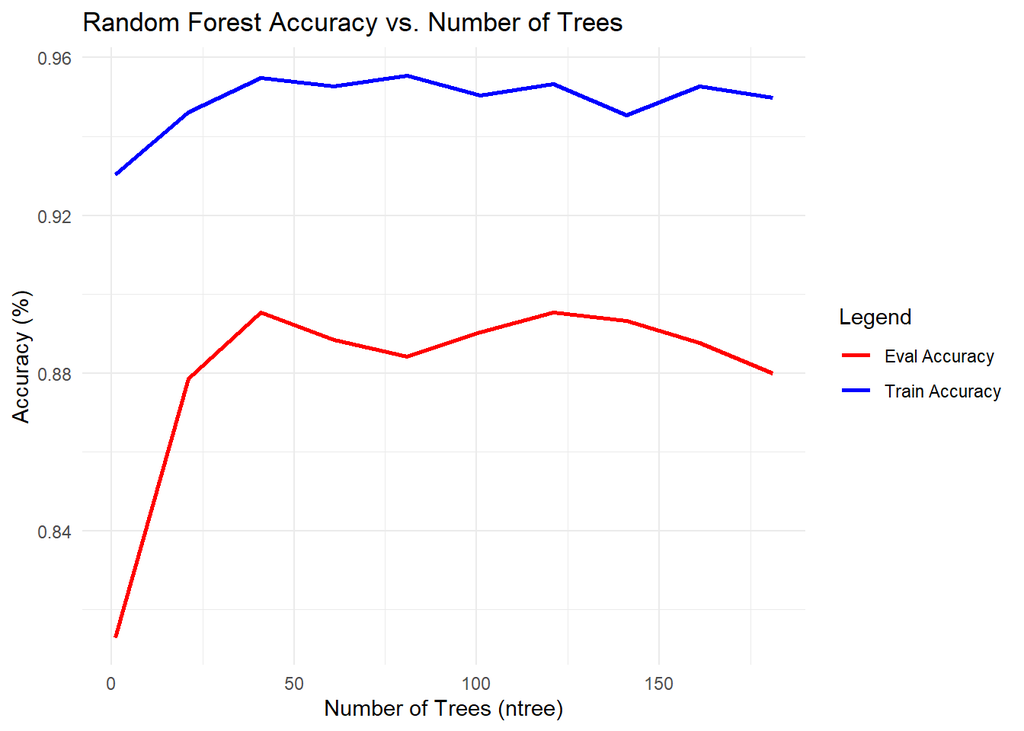

```r
accuracy_df <- data.frame(
  ntree = ntree_list,
  Train_Accuracy = train_accuracies,
  Eval_Accuracy = eval_accuracies
)


library(ggplot2)

ggplot(accuracy_df, aes(x = ntree)) +
  geom_line(aes(y = Train_Accuracy, color = "Train Accuracy"), size = 1) +
  geom_line(aes(y = Eval_Accuracy, color = "Eval Accuracy"), size = 1) +
  labs(title = "Random Forest Accuracy vs. Number of Trees",
       x = "Number of Trees (ntree)",
       y = "Accuracy (%)") +
  scale_color_manual(name = "Legend", values = c("Train Accuracy" = "blue", "Eval Accuracy" = "red")) +
  theme_minimal()
```

*2. Maximum Depth (maxdepth)*

The maximum depth of each tree was varied between 2 and 100 in increments of 3. Limiting the depth helps prevent overfitting by controlling the tree’s complexity.

```r
target_column <- "loan_status"

maxdepth_list <- seq(2, 100, by = 3)
train_accuracies <- c()
eval_accuracies <- c()

for (maxdepth in maxdepth_list) {
  cat("Training Random Forest with", maxdepth, "max depth...\n")

  rf_model <- train_and_evaluate_rf(sample_train_df, sample_eval_df, target_column, ntree=25, maxdepth = maxdepth)


  train_accuracies <- c(train_accuracies, rf_model$train_accuracy)
  eval_accuracies <- c(eval_accuracies, rf_model$eval_accuracy)
}
```

```
## Training Random Forest with 2 max depth...
## Training Random Forest with 5 max depth...
## Training Random Forest with 8 max depth...
## Training Random Forest with 11 max depth...
## Training Random Forest with 14 max depth...
## Training Random Forest with 17 max depth...
## Training Random Forest with 20 max depth...
## Training Random Forest with 23 max depth...
## Training Random Forest with 26 max depth...
## Training Random Forest with 29 max depth...
## Training Random Forest with 32 max depth...
## Training Random Forest with 35 max depth...
## Training Random Forest with 38 max depth...
## Training Random Forest with 41 max depth...
## Training Random Forest with 44 max depth...
## Training Random Forest with 47 max depth...
## Training Random Forest with 50 max depth...
## Training Random Forest with 53 max depth...
## Training Random Forest with 56 max depth...
## Training Random Forest with 59 max depth...
## Training Random Forest with 62 max depth...
## Training Random Forest with 65 max depth...
## Training Random Forest with 68 max depth...
## Training Random Forest with 71 max depth...
## Training Random Forest with 74 max depth...
## Training Random Forest with 77 max depth...
## Training Random Forest with 80 max depth...
## Training Random Forest with 83 max depth...
## Training Random Forest with 86 max depth...
## Training Random Forest with 89 max depth...
## Training Random Forest with 92 max depth...
## Training Random Forest with 95 max depth...
## Training Random Forest with 98 max depth...
```

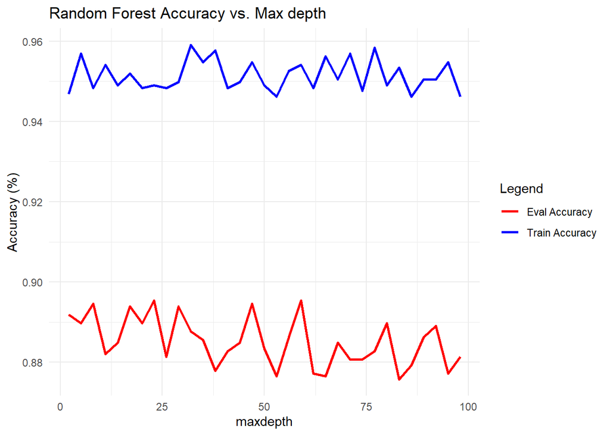

```r
accuracy_df <- data.frame(
  maxdepth = maxdepth_list,
  Train_Accuracy = train_accuracies,
  Eval_Accuracy = eval_accuracies
)


library(ggplot2)

ggplot(accuracy_df, aes(x = maxdepth)) +
  geom_line(aes(y = Train_Accuracy, color = "Train Accuracy"), size = 1) +
  geom_line(aes(y = Eval_Accuracy, color = "Eval Accuracy"), size = 1) +
  labs(title = "Random Forest Accuracy vs. Max depth",
       x = "maxdepth",
       y = "Accuracy (%)") +
  scale_color_manual(name = "Legend", values = c("Train Accuracy" = "blue", "Eval Accuracy" = "red")) +
  theme_minimal()
```

*3. Maximum Nodes (maxnodes)*

The maximum number of terminal nodes (maxnodes) was varied between 2 and 50. Reducing maxnodes can help prevent overfitting by limiting the size of the tree.

```r
target_column <- "loan_status"
sample_train_df <- handle_class_imbalance(train_df, target_column)
sample_eval_df <- handle_class_imbalance(eval_df, target_column)

maxnodes_list <- seq(2, 50, by = 1)
train_accuracies <- c()
eval_accuracies <- c()

for (maxnodes in maxnodes_list) {
  cat("Training Random Forest with", maxnodes, "max nodes...\n")

  rf_model <- train_and_evaluate_rf(sample_train_df, sample_eval_df, target_column, ntree=25, maxdepth = 15, maxnodes = maxnodes)

  train_accuracies <- c(train_accuracies, rf_model$train_accuracy)
  eval_accuracies <- c(eval_accuracies, rf_model$eval_accuracy)
}
```

```
## Training Random Forest with 2 max nodes...
## Training Random Forest with 3 max nodes...
## Training Random Forest with 4 max nodes...
## Training Random Forest with 5 max nodes...
## Training Random Forest with 6 max nodes...
## Training Random Forest with 7 max nodes...
## Training Random Forest with 8 max nodes...
## Training Random Forest with 9 max nodes...
## Training Random Forest with 10 max nodes...
## Training Random Forest with 11 max nodes...
## Training Random Forest with 12 max nodes...
## Training Random Forest with 13 max nodes...
## Training Random Forest with 14 max nodes...
## Training Random Forest with 15 max nodes...
## Training Random Forest with 16 max nodes...
## Training Random Forest with 17 max nodes...
## Training Random Forest with 18 max nodes...
## Training Random Forest with 19 max nodes...
## Training Random Forest with 20 max nodes...
## Training Random Forest with 21 max nodes...
## Training Random Forest with 22 max nodes...
## Training Random Forest with 23 max nodes...
## Training Random Forest with 24 max nodes...
## Training Random Forest with 25 max nodes...
## Training Random Forest with 26 max nodes...
## Training Random Forest with 27 max nodes...
## Training Random Forest with 28 max nodes...
## Training Random Forest with 29 max nodes...
## Training Random Forest with 30 max nodes...
## Training Random Forest with 31 max nodes...
## Training Random Forest with 32 max nodes...
## Training Random Forest with 33 max nodes...
## Training Random Forest with 34 max nodes...
## Training Random Forest with 35 max nodes...
## Training Random Forest with 36 max nodes...
## Training Random Forest with 37 max nodes...
## Training Random Forest with 38 max nodes...
## Training Random Forest with 39 max nodes...
## Training Random Forest with 40 max nodes...
## Training Random Forest with 41 max nodes...
## Training Random Forest with 42 max nodes...
## Training Random Forest with 43 max nodes...
## Training Random Forest with 44 max nodes...
## Training Random Forest with 45 max nodes...
## Training Random Forest with 46 max nodes...
## Training Random Forest with 47 max nodes...
## Training Random Forest with 48 max nodes...
## Training Random Forest with 49 max nodes...
## Training Random Forest with 50 max nodes...
```

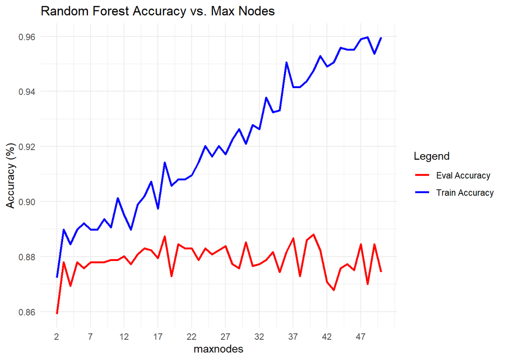

```r
accuracy_df <- data.frame(
  maxnodes = maxnodes_list,
  Train_Accuracy = train_accuracies,
  Eval_Accuracy = eval_accuracies
)


library(ggplot2)

ggplot(accuracy_df, aes(x = maxnodes)) +
  geom_line(aes(y = Train_Accuracy, color = "Train Accuracy"), size = 1) +
  geom_line(aes(y = Eval_Accuracy, color = "Eval Accuracy"), size = 1) +
  labs(title = "Random Forest Accuracy vs. Max Nodes",
       x = "maxnodes",
       y = "Accuracy (%)") +
  scale_color_manual(name = "Legend", values = c("Train Accuracy" = "blue", "Eval Accuracy" = "red")) +
  scale_x_continuous(breaks = seq(min(accuracy_df$maxnodes), max(accuracy_df$maxnodes), by = 5)) +
  theme_minimal()
```

*4. Class Weights*

To handle class imbalance, different weights for the “Charged Off” class were tested (ranging from 1 to 10). Assigning a higher weight to the minority class improves its recall, ensuring the model doesn’t overlook high-risk loans.

```r
target_column <- "loan_status"
sample_train_df <- handle_class_imbalance(train_df, target_column)
sample_eval_df <- handle_class_imbalance(eval_df, target_column)

chareoff_class_wt_list <- seq(1, 10, by = 1)
train_accuracies <- c()
eval_accuracies <- c()

for (chareoff_class_wt in chareoff_class_wt_list) {
  cat("Training Random Forest with", chareoff_class_wt, " chareoff_class_wt...\n")

  rf_model <- train_and_evaluate_rf(sample_train_df, sample_eval_df, target_column, ntree=25, maxdepth = 25,
                                    maxnodes = 17, classwt = c("Charged Off" = chareoff_class_wt, "Fully Paid" = 1))


  train_accuracies <- c(train_accuracies, rf_model$train_accuracy)
  eval_accuracies <- c(eval_accuracies, rf_model$eval_accuracy)
}
```

```
## Training Random Forest with 1  chareoff_class_wt...
## Training Random Forest with 2  chareoff_class_wt...
## Training Random Forest with 3  chareoff_class_wt...
## Training Random Forest with 4  chareoff_class_wt...
## Training Random Forest with 5  chareoff_class_wt...
## Training Random Forest with 6  chareoff_class_wt...
## Training Random Forest with 7  chareoff_class_wt...
## Training Random Forest with 8  chareoff_class_wt...
## Training Random Forest with 9  chareoff_class_wt...
## Training Random Forest with 10  chareoff_class_wt...
```

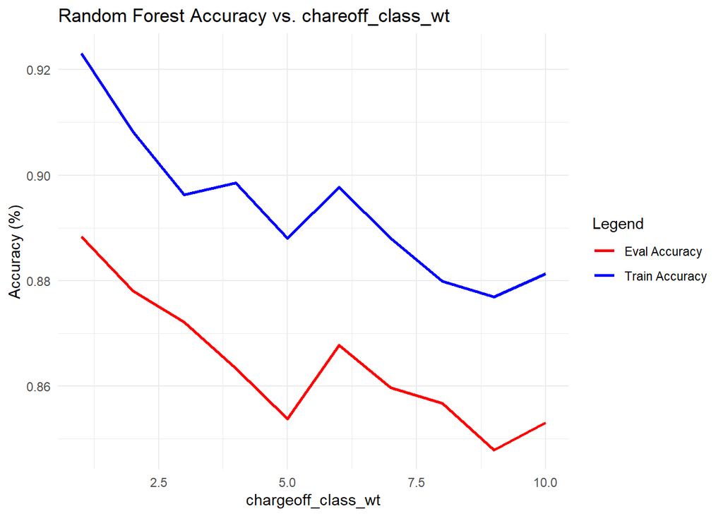

```r
accuracy_df <- data.frame(
  chareoff_class_wt = chareoff_class_wt_list,
  Train_Accuracy = train_accuracies,
  Eval_Accuracy = eval_accuracies
)


library(ggplot2)

ggplot(accuracy_df, aes(x = chareoff_class_wt)) +
  geom_line(aes(y = Train_Accuracy, color = "Train Accuracy"), size = 1) +
  geom_line(aes(y = Eval_Accuracy, color = "Eval Accuracy"), size = 1) +
  labs(title = "Random Forest Accuracy vs. chareoff_class_wt",
       x = "chargeoff_class_wt",
       y = "Accuracy (%)") +
  scale_color_manual(name = "Legend", values = c("Train Accuracy" = "blue", "Eval Accuracy" = "red")) +
  theme_minimal()
```

*Tuning Class Weights* The class weights for “Charged Off” and “Fully Paid” were varied independently:

Charged Off Weights (chareoff_class_wt_list): Ranges from 1 to 10. Fully Paid Weights (fully_paid_class_wt_list): Ranges from 1 to 10. The grid search approach was used to evaluate all combinations of these weights, with the Random Forest model trained and evaluated for each combination.

```r
chareoff_class_wt_list <- seq(1, 10, by = 1)
fully_paid_class_wt_list <- seq(1, 10, by = 1)

train_precision_charged_off <- c()
eval_precision_charged_off <- c()
train_recall_charged_off <- c()
eval_recall_charged_off <- c()

train_precision_fully_paid <- c()
eval_precision_fully_paid <- c()
train_recall_fully_paid <- c()
eval_recall_fully_paid <- c()


for (chareoff_class_wt in chareoff_class_wt_list) {
  for (fully_paid_class_wt in fully_paid_class_wt_list) {
    cat("Training Random Forest with Charged Off Weight:", chareoff_class_wt,
        " Fully Paid Weight:", fully_paid_class_wt, "...\n")


    rf_model <- train_and_evaluate_rf(
      sample_train_df, sample_eval_df, target_column,
      ntree = 120, maxdepth = 25, maxnodes = 20,
      classwt = c("Charged Off" = chareoff_class_wt, "Fully Paid" = fully_paid_class_wt)
    )

    metrics <- calculate_metrics(rf_model)


    cat("Train - Charged Off Class:\n")
    cat("Precision: ", metrics$train_precision_charged_off, "\n")
    cat("Recall: ", metrics$train_recall_charged_off, "\n")
    cat("F1: ", metrics$train_f1_charged_off, "\n")


    train_precision_charged_off <- c(train_precision_charged_off, metrics$train_precision_charged_off)
    eval_precision_charged_off <- c(eval_precision_charged_off, metrics$eval_precision_charged_off)

    train_recall_charged_off <- c(train_recall_charged_off, metrics$train_recall_charged_off)
    eval_recall_charged_off <- c(eval_recall_charged_off, metrics$eval_recall_charged_off)


    train_precision_fully_paid <- c(train_precision_fully_paid, metrics$train_precision_fully_paid)
    eval_precision_fully_paid <- c(eval_precision_fully_paid, metrics$eval_precision_fully_paid)

    train_recall_fully_paid <- c(train_recall_fully_paid, metrics$train_recall_fully_paid)
    eval_recall_fully_paid <- c(eval_recall_fully_paid, metrics$eval_recall_fully_paid)
  }
}
```

```
## Training Random Forest with Charged Off Weight: 1  Fully Paid Weight: 1 ...
## Train - Charged Off Class:
## Precision:  0.961
## Recall:  0.873
## F1:  0.915
## Training Random Forest with Charged Off Weight: 1  Fully Paid Weight: 2 ...
## Train - Charged Off Class:
## Precision:  0.907
## Recall:  0.882
## F1:  0.894
## Training Random Forest with Charged Off Weight: 1  Fully Paid Weight: 3 ...
## Train - Charged Off Class:
## Precision:  0.882
## Recall:  0.9
## F1:  0.891
## Training Random Forest with Charged Off Weight: 1  Fully Paid Weight: 4 ...
## Train - Charged Off Class:
## Precision:  0.864
## Recall:  0.91
## F1:  0.886
## Training Random Forest with Charged Off Weight: 1  Fully Paid Weight: 5 ...
## Train - Charged Off Class:
## Precision:  0.839
## Recall:  0.936
## F1:  0.885
## Training Random Forest with Charged Off Weight: 1  Fully Paid Weight: 6 ...
## Train - Charged Off Class:
## Precision:  0.823
## Recall:  0.947
## F1:  0.881
## Training Random Forest with Charged Off Weight: 1  Fully Paid Weight: 7 ...
## Train - Charged Off Class:
## Precision:  0.777
## Recall:  0.969
## F1:  0.862
## Training Random Forest with Charged Off Weight: 1  Fully Paid Weight: 8 ...
## Train - Charged Off Class:
## Precision:  0.743
## Recall:  0.983
## F1:  0.846
```

[output cut: 445 more lines]

```
## Training Random Forest with Charged Off Weight: 10  Fully Paid Weight: 8 ...
## Train - Charged Off Class:
## Precision:  0.971
## Recall:  0.868
## F1:  0.917
## Training Random Forest with Charged Off Weight: 10  Fully Paid Weight: 9 ...
## Train - Charged Off Class:
## Precision:  0.966
## Recall:  0.87
## F1:  0.915
## Training Random Forest with Charged Off Weight: 10  Fully Paid Weight: 10 ...
## Train - Charged Off Class:
## Precision:  0.959
## Recall:  0.872
## F1:  0.913
```

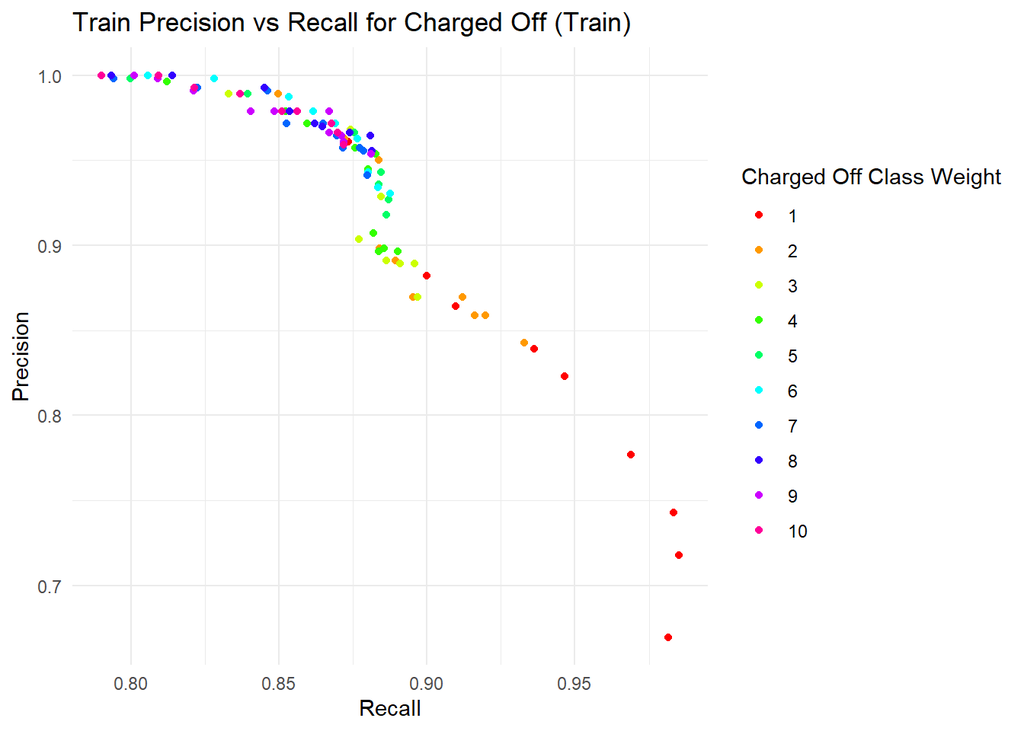

```r
plot_data <- data.frame(
  chareoff_class_wt = rep(chareoff_class_wt_list, each = length(fully_paid_class_wt_list)),
  fully_paid_class_wt = rep(fully_paid_class_wt_list, times = length(chareoff_class_wt_list)),
  train_precision_charged_off = train_precision_charged_off,
  eval_precision_charged_off = eval_precision_charged_off,
  train_recall_charged_off = train_recall_charged_off,
  eval_recall_charged_off = eval_recall_charged_off,
  train_precision_fully_paid = train_precision_fully_paid,
  eval_precision_fully_paid = eval_precision_fully_paid,
  train_recall_fully_paid = train_recall_fully_paid,
  eval_recall_fully_paid = eval_recall_fully_paid
)

# Create scatter plots using ggplot
library(ggplot2)

# Plot Precision vs Recall for Charged Off class (Train vs Eval)
ggplot(plot_data, aes(x = train_recall_charged_off, y = train_precision_charged_off,
                     color = as.factor(chareoff_class_wt))) +
  geom_point() +
  labs(title = "Train Precision vs Recall for Charged Off (Train)",
       x = "Recall", y = "Precision") +
  scale_color_manual(name = "Charged Off Class Weight", values = rainbow(length(chareoff_class_wt_list))) +
  theme_minimal()
```

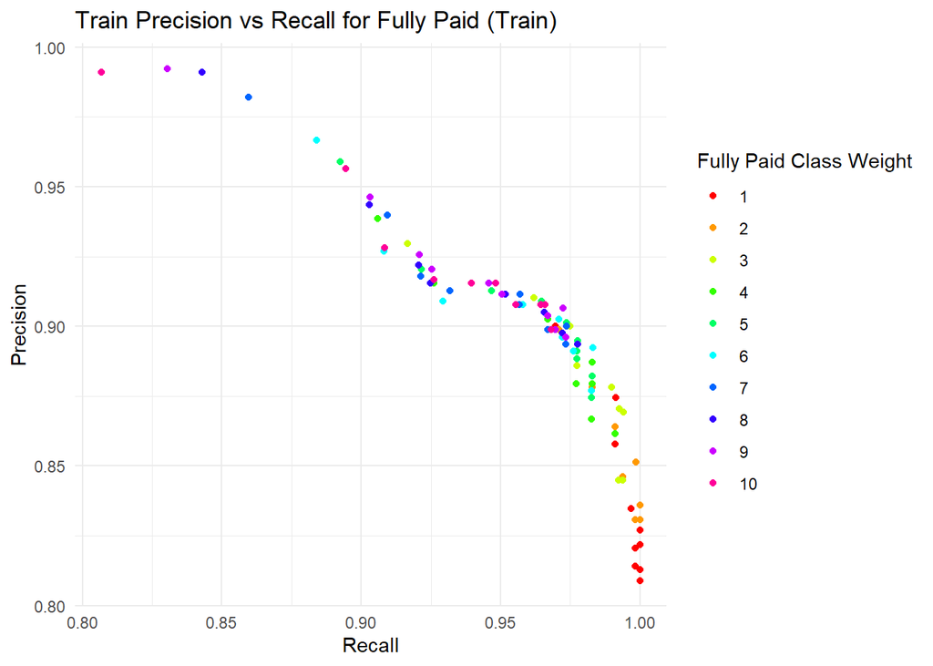

```r
# Plot Precision vs Recall for Fully Paid class (Train vs Eval)
ggplot(plot_data, aes(x = train_recall_fully_paid, y = train_precision_fully_paid,
                     color = as.factor(fully_paid_class_wt))) +
  geom_point() +
  labs(title = "Train Precision vs Recall for Fully Paid (Train)",
       x = "Recall", y = "Precision") +
  scale_color_manual(name = "Fully Paid Class Weight", values = rainbow(length(fully_paid_class_wt_list))) +
  theme_minimal()
```

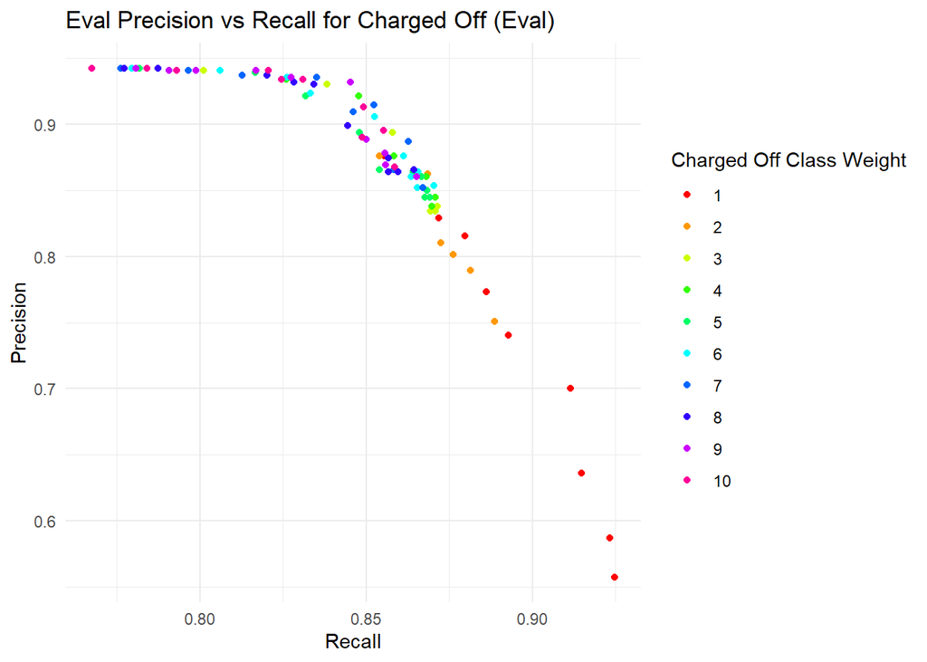

```r
# Plot Eval Precision vs Recall for Charged Off class
ggplot(plot_data, aes(x = eval_recall_charged_off, y = eval_precision_charged_off,
                     color = as.factor(chareoff_class_wt))) +
  geom_point() +
  labs(title = "Eval Precision vs Recall for Charged Off (Eval)",
       x = "Recall", y = "Precision") +
  scale_color_manual(name = "Charged Off Class Weight", values = rainbow(length(chareoff_class_wt_list))) +
  theme_minimal()
```

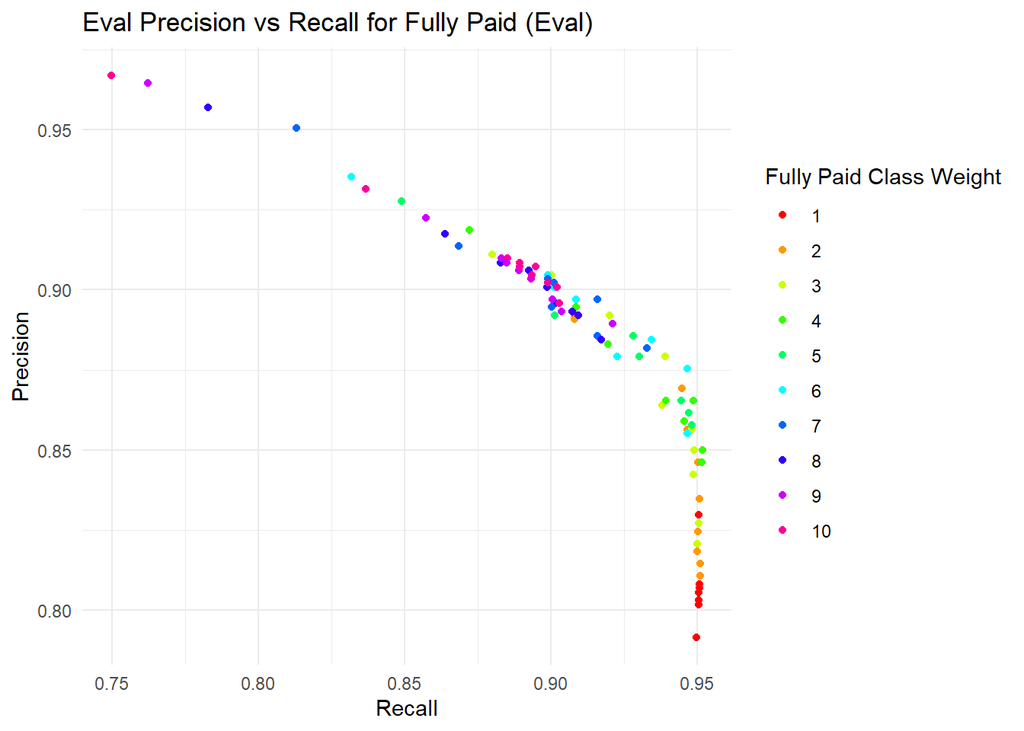

```r
# Plot Eval Precision vs Recall for Fully Paid class
ggplot(plot_data, aes(x = eval_recall_fully_paid, y = eval_precision_fully_paid,
                     color = as.factor(fully_paid_class_wt))) +
  geom_point() +
  labs(title = "Eval Precision vs Recall for Fully Paid (Eval)",
       x = "Recall", y = "Precision") +
  scale_color_manual(name = "Fully Paid Class Weight", values = rainbow(length(fully_paid_class_wt_list))) +
  theme_minimal()
```

## Train Model on Whole Train Dataset

### Explanation of Final Model Evaluation

The **final Random Forest model** was trained and evaluated using the optimized hyperparameters. The following results summarize the performance metrics for both the “Charged Off” and “Fully Paid” classes.

### 1. **Model Configuration**

- **Number of Trees (`ntree`)**: 25
- **Maximum Depth (`maxdepth`)**: 25
- **Maximum Nodes (`maxnodes`)**: 17
- **Training Data**: `train_df`
- **Evaluation Data**: `eval_df`
- **Target Column**: `loan_status`

#### Code:

```r
final_results <- train_and_evaluate_rf(train_df, eval_df, target_column, ntree = 25, maxdepth = 25, maxnodes = 17)
```

### 2. **Performance Metrics**

Metrics such as **precision**, **recall**, and **F1-score** were computed for both classes (“Charged Off” and “Fully Paid”) on the training and evaluation datasets.

#### Results:

```r
metrics <- calculate_metrics(final_results)

cat("Train - Charged Off Class:\n")
```

```
## Train - Charged Off Class:
```

```r
cat("Precision: ", metrics$train_precision_charged_off, "\n")
```

```
## Precision:  0.84
```

```r
cat("Recall: ", metrics$train_recall_charged_off, "\n")
```

```
## Recall:  0.726
```

```r
cat("F1: ", metrics$train_f1_charged_off, "\n")
```

```
## F1:  0.779
```

```r
cat("\nTrain - Fully Paid Class:\n")
```

```
##
## Train - Fully Paid Class:
```

```r
cat("Precision: ", metrics$train_precision_fully_paid, "\n")
```

```
## Precision:  0.919
```

```r
cat("Recall: ", metrics$train_recall_fully_paid, "\n")
```

```
## Recall:  0.958
```

```r
cat("F1: ", metrics$train_f1_fully_paid, "\n")
```

```
## F1:  0.938
```

```r
cat("\nEval - Charged Off Class:\n")
```

```
##
## Eval - Charged Off Class:
```

```r
cat("Precision: ", metrics$eval_precision_charged_off, "\n")
```

```
## Precision:  0.842
```

```r
cat("Recall: ", metrics$eval_recall_charged_off, "\n")
```

```
## Recall:  0.728
```

```r
cat("F1: ", metrics$eval_f1_charged_off, "\n")
```

```
## F1:  0.781
```

```r
cat("\nEval - Fully Paid Class:\n")
```

```
##
## Eval - Fully Paid Class:
```

```r
cat("Precision: ", metrics$eval_precision_fully_paid, "\n")
```

```
## Precision:  0.92
```

```r
cat("Recall: ", metrics$eval_recall_fully_paid, "\n")
```

```
## Recall:  0.958
```

```r
cat("F1: ", metrics$eval_f1_fully_paid, "\n")
```

```
## F1:  0.938
```

### 3. **Interpretation**

#### Charged Off Class:

- **Precision**: Measures the proportion of correctly predicted “Charged Off” loans out of all loans classified as “Charged Off.”
- **Recall**: Indicates the proportion of actual “Charged Off” loans that were correctly identified.
- **F1-Score**: Balances precision and recall to provide a comprehensive performance measure.

#### Fully Paid Class:

- **Precision**: Reflects the proportion of correctly predicted “Fully Paid” loans out of all loans classified as “Fully Paid.”
- **Recall**: Captures the proportion of actual “Fully Paid” loans that were correctly identified.
- **F1-Score**: Combines precision and recall into a single metric for model evaluation.

### Insights

1. **Training Performance**:
   - High precision and recall values for “Fully Paid” indicate that the model performs well on the majority class.
   - The metrics for “Charged Off” highlight the model’s ability to handle the minority class effectively.
2. **Evaluation Performance**:
   - The evaluation metrics validate that the model generalizes well to unseen data.
   - Differences between training and evaluation metrics suggest the degree of overfitting (if any).
3. **Balanced Metrics**:
   - The F1-score provides a balanced measure of the model’s performance across both classes, ensuring that neither precision nor recall is disproportionately optimized.

### Evaluating Thresholds for Class Predictions

This analysis evaluates how different probability thresholds affect the precision, recall, and F1-score for predicting the “Charged Off” class. Adjusting the threshold allows for a balance between identifying more true positives (high recall) and reducing false positives (high precision).

### 1. **Function Overview**

- **`evaluate_thresholds`**:
  - Iterates through a series of probability thresholds (e.g., 0.1 to 0.9).
  - At each threshold, classifies loans as “Charged Off” or “Fully Paid” based on their predicted probabilities.
  - Computes performance metrics (precision, recall, F1-score) for the “Charged Off” class using a confusion matrix.
- **`calculate_class_metrics`**:
  - Calculates precision, recall, and F1-score for a specific class from the confusion matrix.

```r
evaluate_thresholds <- function(model, eval_df, prob_thresholds, calculate_class_metrics) {
  if (!"loan_status" %in% names(eval_df)) {
    stop("The evaluation dataframe must contain a 'loan_status' column.")
  }

  threshold_results <- list()

  for (threshold in prob_thresholds) {
    predictions <- predict(model, eval_df, type = "prob")
    charged_off_probs <- predictions[, "Charged Off"]

    predicted_classes <- ifelse(charged_off_probs >= threshold, "Charged Off", "Fully Paid")

    conf_matrix <- table(predicted_classes, eval_df$loan_status)

    metrics <- calculate_class_metrics(conf_matrix, class = "Charged Off")

    threshold_results[[as.character(threshold)]] <- list(
      precision = metrics[1],
      recall = metrics[2],
      f1 = metrics[3]
    )
  }

  threshold_df <- do.call(rbind, lapply(threshold_results, function(x) {
    cbind(precision = x$precision, recall = x$recall, f1 = x$f1)
  }))

  threshold_df <- cbind(threshold = prob_thresholds, threshold_df)

  return(threshold_df)
}

calculate_class_metrics <- function(conf_matrix, class) {
  if (!(class %in% rownames(conf_matrix) && class %in% colnames(conf_matrix))) {
    stop("The specified class is not in the confusion matrix.")
  }

  class_index <- which(rownames(conf_matrix) == class)

  tp <- conf_matrix[class, class]  # True Positives
  fn <- sum(conf_matrix[class, -class_index])  # False Negatives
  fp <- sum(conf_matrix[-class_index, class])  # False Positives
  tn <- sum(conf_matrix) - tp - fn - fp  # True Negatives

  precision <- tp / (tp + fp)
  recall <- tp / (tp + fn)
  f1 <- 2 * (precision * recall) / (precision + recall)

  return(c(precision, recall, f1))
}
```

### 2. **Evaluating Thresholds**

We evaluated thresholds ranging from 0.1 to 0.9 in increments of 0.1. And in each threshold: - Probabilities are converted to class predictions. - A confusion matrix is generated to compute precision, recall, and F1-score.

```r
prob_thresholds <- seq(0.1, 0.9, by = 0.1)
threshold_metrics <- evaluate_thresholds(final_results$model, eval_df, prob_thresholds, calculate_class_metrics)
```

### 3. **Visualizing Precision-Recall Trade-offs**

The precision and recall values for each threshold are visualized using a line chart to observe their trade-off: - **Precision**: Proportion of correctly identified “Charged Off” loans among all loans classified as “Charged Off.” - **Recall**: Proportion of actual “Charged Off” loans that were correctly identified.

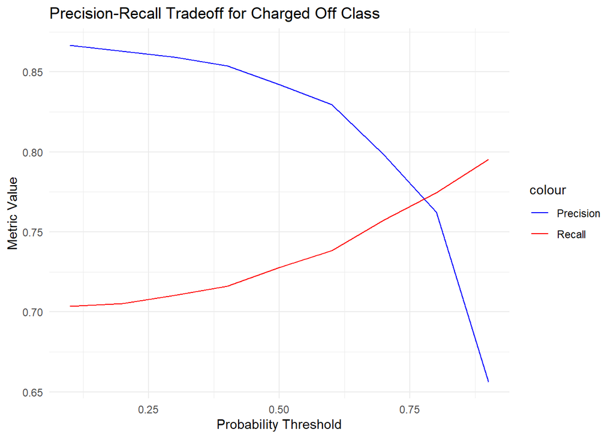

```r
library(ggplot2)

ggplot(threshold_metrics, aes(x = threshold)) +
  geom_line(aes(y = precision, color = "Precision")) +
  geom_line(aes(y = recall, color = "Recall")) +
  labs(title = "Precision-Recall Tradeoff for Charged Off Class",
       x = "Probability Threshold",
       y = "Metric Value") +
  theme_minimal() +
  scale_color_manual(values = c("Precision" = "blue", "Recall" = "red"))
```

### Insights

This approach provides a flexible framework to adapt the Random Forest model to specific business priorities.

Now we have our full model, Let’s test it. Random Forest model’s accuracy on the test dataset by analyzing precision, recall, and the Receiver Operating Characteristic (ROC) curve. Here’s a breakdown of our process:

### **Evaluating Metrics for Test Data**

The function `evaluate_model_metrics` computes precision and recall for the “Charged Off” and “Fully Paid” classes using a specified probability threshold.

#### Key Steps:

1. **Probability Predictions**:
   - The model predicts probabilities for each class.
   - Predictions with probabilities above the `charge_off_threshold` are classified as “Charged Off”; others as “Fully Paid.”
2. **Confusion Matrix**:
   - The confusion matrix compares predicted classes to actual loan statuses.
3. **Precision and Recall**:
   - **Precision**: Ratio of true positive predictions to all positive predictions.
   - **Recall**: Ratio of true positive predictions to all actual positives.

```r
evaluate_model_metrics <- function(df, model, charge_off_threshold) {
  if (!"loan_status" %in% names(df)) {
    stop("The dataframe must contain a 'loan_status' column.")
  }

  pred_probs <- predict(model, df, type = "prob")

  predicted_classes <- apply(pred_probs, 1, function(row) {
    if (row["Charged Off"] >= charge_off_threshold) {
      return("Charged Off")
    } else {
      return("Fully Paid")
    }
  })

  predicted_classes <- factor(predicted_classes, levels = levels(df$loan_status))

  conf_matrix <- table(Predicted = predicted_classes, Actual = df$loan_status)

  calculate_metrics_for_class <- function(class_name) {
    tp <- conf_matrix[class_name, class_name]  # True Positives
    fn <- sum(conf_matrix[class_name, ]) - tp  # False Negatives
    fp <- sum(conf_matrix[, class_name]) - tp  # False Positives
    tn <- sum(conf_matrix) - tp - fn - fp  # True Negatives

    precision <- tp / (tp + fp)
    recall <- tp / (tp + fn)
    return(c(Precision = precision, Recall = recall))
  }

  class_metrics <- lapply(levels(df$loan_status), function(class_name) {
    calculate_metrics_for_class(class_name)
  })

  metrics_df <- do.call(rbind, class_metrics)
  rownames(metrics_df) <- levels(df$loan_status)

  return(metrics_df)
}

# Example Usage
test_metrics <- evaluate_model_metrics(test_df, final_results$model, 0.7)
print(test_metrics)
```

```
##             Precision Recall
## Charged Off     0.798  0.751
## Fully Paid      0.933  0.948
```

### **Receiver Operating Characteristic (ROC) Curve**

The ROC curve visualizes the model’s ability to distinguish between “Charged Off” and “Fully Paid” classes across different thresholds. The **Area Under the Curve (AUC)** quantifies the model’s overall performance: - **AUC** values closer to 1 indicate better performance. - **AUC = 0.5** represents a random guess.

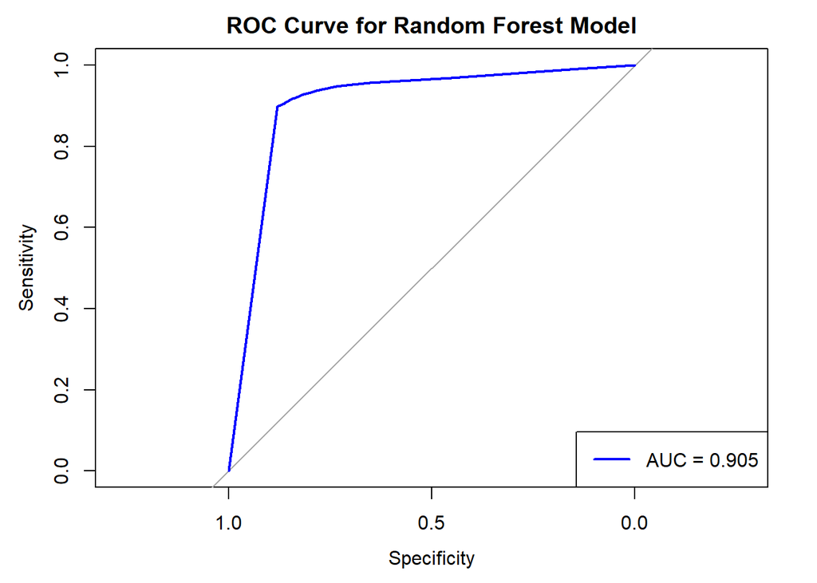

```r
library(pROC)

# Generate predictions and true labels
predictions <- predict(final_results$model, test_df, type = "prob")
positive_class_prob <- predictions[, "Charged Off"]
true_labels <- test_df$loan_status

# Compute ROC and AUC
roc_curve <- roc(response = true_labels, predictor = positive_class_prob)

# Plot ROC Curve
plot(roc_curve, col = "blue", main = "ROC Curve for Random Forest Model")
auc <- auc(roc_curve)
legend("bottomright", legend = paste("AUC =", round(auc, 3)), col = "blue", lwd = 2)
```

### 3. **Insights**

1. **Precision and Recall**:
   - Evaluate the trade-offs between precision and recall for the “Charged Off” class.
   - Determine whether the model prioritizes minimizing false positives (high precision) or false negatives (high recall).
2. **ROC and AUC**:
   - A high AUC indicates the model performs well in separating “Charged Off” loans from “Fully Paid” loans.
   - The ROC curve allows for visual inspection of the model’s performance across thresholds.
3. **Threshold Adjustments**:
   - Using different thresholds (e.g., 0.7, 0.5) enables fine-tuning for specific business priorities (e.g., risk minimization).

These metrics collectively assess the model’s ability to generalize to unseen data, providing a robust evaluation of its predictive accuracy.

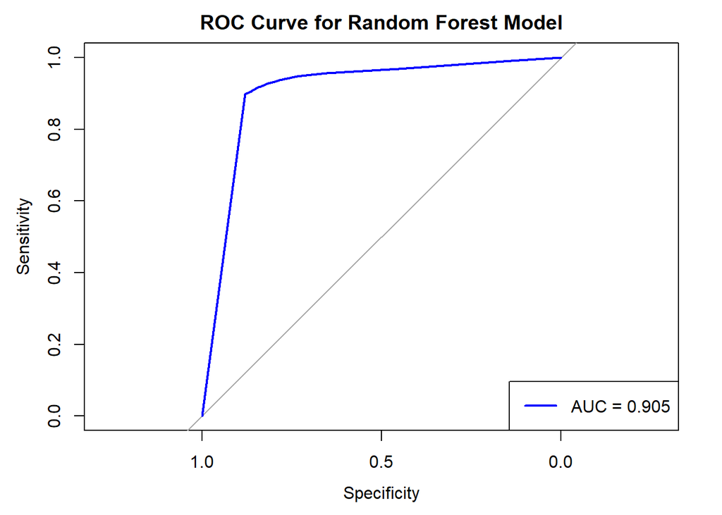

```r
library(pROC)
predictions <- predict(final_results$model, test_df, type = "prob")

positive_class_prob <- predictions[, "Charged Off"]

true_labels <- test_df$loan_status

roc_curve <- roc(response = true_labels, predictor = positive_class_prob)

plot(roc_curve, col = "blue", main = "ROC Curve for Random Forest Model")
auc <- auc(roc_curve)
legend("bottomright", legend = paste("AUC =", round(auc, 3)), col = "blue", lwd = 2)
```

### Randomized Accuracy Testing and Prediction

### **Randomized Accuracy Testing**

Now we are evaluating the **stability** of our Random Forest model by repeatedly sampling and testing its accuracy on subsets of the test dataset. We aim to understand how the model performs under varying class distributions.

#### Key Steps:

**Random Sampling**: - A subset of the test data is sampled using the `handle_class_imbalance` function to address class imbalance in each iteration.

**Accuracy Calculation**: - For each sampled dataset, the model’s predictions are compared to the true labels to compute accuracy.

**Histogram Visualization**: - A histogram illustrates the distribution of accuracies across multiple iterations.

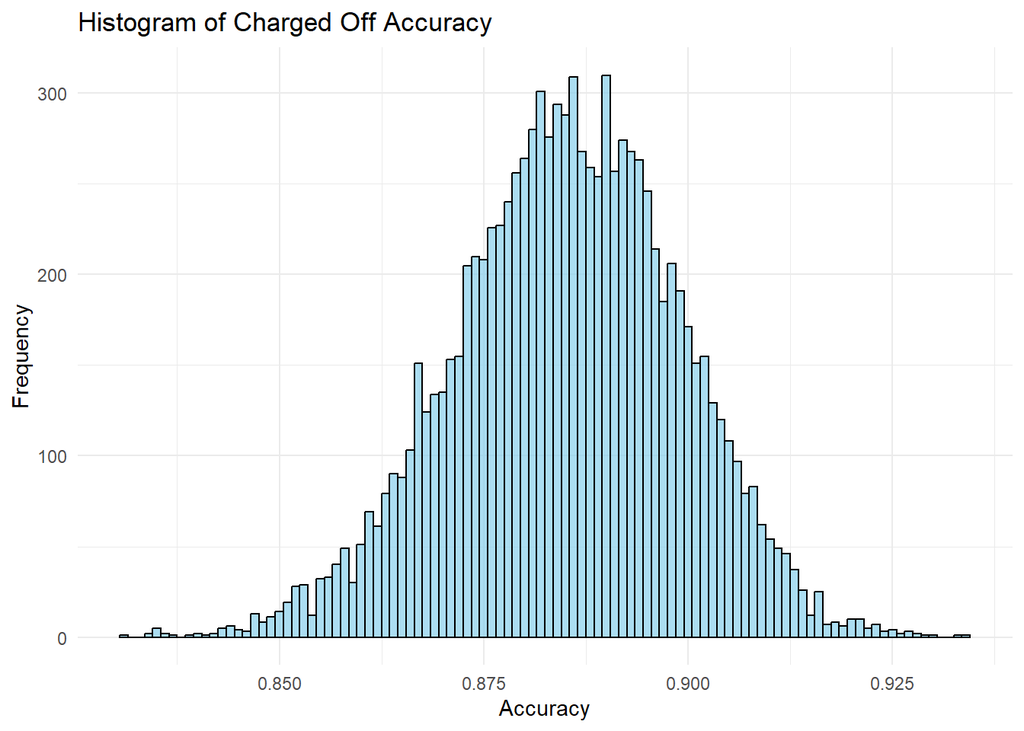

```r
N <- 10000
accuracies <- numeric(N)

calculate_accuracy <- function(model, sample_data) {
  predictions <- predict(model, sample_data, type = "response")
  true_labels <- sample_data$loan_status
  charged_off_accuracy <- mean(predictions == true_labels)
  return(charged_off_accuracy)
}

for (i in 1:N) {
  sample_test_df <- handle_class_imbalance(test_df, "loan_status")
  accuracy <- calculate_accuracy(final_results$model, sample_test_df)
  accuracies[i] <- accuracy
}

# Plot histogram of accuracies
ggplot(data.frame(accuracy = accuracies), aes(x = accuracy)) +
  geom_histogram(binwidth = 0.001, fill = "skyblue", color = "black", alpha = 0.7) +
  labs(title = "Histogram of Charged Off Accuracy", x = "Accuracy", y = "Frequency") +
  theme_minimal()
```

#### Insights:

- **Histogram**: Displays how often the model achieves a specific accuracy across different samples.
- **Model Stability**: A tight concentration around a mean accuracy indicates consistent model performance.

### **Predicting Loan Outcomes**

This step applies the trained model to predict loan outcomes (Charged Off or Fully Paid) for active loans issued between 2015 and 2018.

#### Key Steps:

**Probability Predictions**: - The model predicts the probability of each loan being “Charged Off.”

**Threshold-based Classification**: - Loans with a “Charged Off” probability above the specified threshold (e.g., 0.7) are classified as “Charged Off.”

**Outcome Summary**: - The total counts of predicted “Charged Off” and “Fully Paid” loans are calculated and their percentages are displayed.

```r
calculate_loan_outcomes_with_probs <- function(model, predict_df, threshold = 0.5) {
  prob_predictions <- predict(model, predict_df, type = "prob")
  charged_off_probs <- prob_predictions[, "Charged Off"]

  predictions <- ifelse(charged_off_probs >= threshold, "Charged Off", "Fully Paid")

  outcome_counts <- table(predictions)
  charged_off_count <- if ("Charged Off" %in% names(outcome_counts)) outcome_counts["Charged Off"] else 0
  fully_paid_count <- if ("Fully Paid" %in% names(outcome_counts)) outcome_counts["Fully Paid"] else 0

  return(list(
    Charged_Off = charged_off_count,
    Fully_Paid = fully_paid_count,
    Charged_Off_Probs = charged_off_probs
  ))
}

results <- calculate_loan_outcomes_with_probs(final_results$model, predict_df, 0.7)

filtered_probs <- results$Charged_Off_Probs[results$Charged_Off_Probs >= 0.5]

cat("Predicting Charged Off % from 2015 to 2018 Active/Current loans: \n")
```

```
## Predicting Charged Off % from 2015 to 2018 Active/Current loans:
```

```r
cat("Total Charged Off:", results$Charged_Off, "(", (results$Charged_Off / (results$Charged_Off + results$Fully_Paid)) * 100, "% )\n")
```

```
## Total Charged Off: 182428 ( 21.1 % )
```

```r
cat("Total Fully Paid:", results$Fully_Paid, "(", (results$Fully_Paid / (results$Charged_Off + results$Fully_Paid)) * 100, "% )\n")
```

```
## Total Fully Paid: 681185 ( 78.9 % )
```

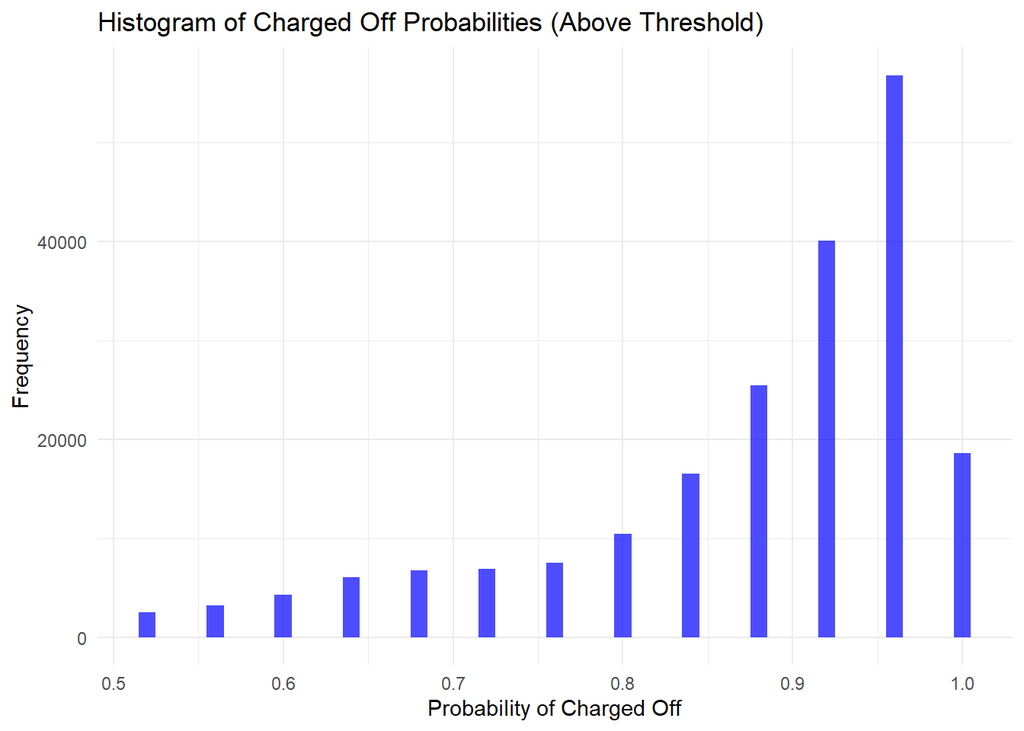

```r
# Plot histogram of Charged Off probabilities above the threshold
ggplot(data.frame(Charged_Off_Probs = filtered_probs), aes(x = Charged_Off_Probs)) +
  geom_histogram(binwidth = 0.01, fill = "blue", alpha = 0.7) +
  labs(
    title = "Histogram of Charged Off Probabilities (Above Threshold)",
    x = "Probability of Charged Off",
    y = "Frequency"
  ) +
  theme_minimal()
```

#### Insights:

- **Prediction Summary**:
  - The total number and percentage of loans predicted as “Charged Off” and “Fully Paid” provide a high-level view of model outcomes.
- **Probability Histogram**:
  - Highlights the distribution of high-risk loans, assisting in further risk stratification.

# Final Conclusion

This report is demonstrating our skills and understanding we’ve gained throughout the fall semester at the George Washington University. In this report we’ve evaluated the effectiveness of classification models, particularly **Logistic Regression** and **Random Forest**, for predicting loan charge-offs using LendingClub loan data from 2013-2018. The key findings and takeaways are summarized below:

The results suggest that **Random Forest** is the better model for predicting loan charge-offs in this dataset, given its ability to:

- Handle non-linear relationships.
- Address class imbalance.
- Provide flexible threshold-based predictions to suit various business objectives.

While Logistic Regression offers simplicity and interpretability, it may not fully capture the complexity of the data, especially when the classes are imbalanced or relationships are non-linear.

### Recommendations for future models:

1. **Operational Use**:
   - Implement the Random Forest model for ongoing monitoring of loan charge-off risk, with dynamic threshold tuning based on evolving business needs.
2. **Future Improvements**:
   - Consider ensemble approaches combining Logistic Regression and Random Forest for enhanced prediction stability.
   - Explore other advanced models like Gradient Boosting or XGBoost for potentially higher accuracy.
3. **Data Collection**:
   - Incorporate additional variables, such as borrower behavior and macroeconomic factors, to improve model precision and predictive power.
4. **Business Application**:
   - Use the predicted probabilities from the Random Forest model to prioritize risk mitigation strategies, such as proactive loan restructuring or enhanced underwriting criteria.